# Business Analytics Project 2

Richard Pham

11/17/2021

# Packages Loaded

```r
library(tidyverse)
library(forecast)
library(ggcorrplot)
library(reshape2)
library(DT)
library(tidymodels)
library(caret)
library(DAAG)
library(cluster)
library(factoextra)
library(cluster.datasets)
library(rpart)
library(rpart.plot)
```

# Importing Data

```r
database <- read.csv("database.csv")
```

# Introduction

The data being analyzed in this project is fuel economy data collected by the U.S. EPA. The data shows vehicle manufacturer, year, model, class of vehicle, highway MPG, city MPG, etc. The goal is to use the provided dataset to analyze, transform, and visualize the data. From a first glance, there seems to be sufficient data to create transformations, visuals and to model.

# Part 1 - Data Analysis, Transformations & Visualizations

## Data Transformations

### Combined Fuel Economy vs Fuel Type

```r
database_fuel <- database %>%
  filter(!grepl("Electricity|and|or", Fuel.Type))
database_fuel %>%
  group_by(Fuel.Type) %>%
  summarise(n = n(), mean = mean(Combined.MPG..FT1.), median = median(Combined.MPG..FT1.), sd = sd(Combined.MPG..FT1.)) %>%
  print()
```

```
## # A tibble: 5 x 5
##   Fuel.Type     n  mean median    sd
##   <chr>     <int> <dbl>  <dbl> <dbl>
## 1 CNG          60  18.1   14.5  7.44
## 2 Diesel     1014  23.4   21    6.86
## 3 Midgrade     77  17.4   17    1.84
## 4 Premium   10133  19.3   19    4.06
## 5 Regular   25258  20.2   20    5.28
```

The data transformation above shows the mean, median, and standard deviation for Combined MPG by Fuel Type, filtering out electric vehicles.

### Vehicles Made After 2005 with City MPG < 9

```r
database %>%
  select(Year, Make, Model) %>%
  filter(database$City.MPG..FT1. < 9, Year > 2005) %>%
  print()
```

```
##    Year        Make                Model
## 1  2006     Bugatti               Veyron
## 2  2006       Dodge  Ram 1500 Pickup 2WD
## 3  2006 Lamborghini L-147/148 Murcielago
## 4  2007 Lamborghini L-147/148 Murcielago
## 5  2008     Bugatti               Veyron
## 6  2008 Lamborghini           Murcielago
## 7  2008 Lamborghini  Murcielago Roadster
## 8  2009 Lamborghini           Murcielago
## 9  2009 Lamborghini  Murcielago Roadster
## 10 2010     Bugatti               Veyron
## 11 2010 Lamborghini           Murcielago
## 12 2010 Lamborghini  Murcielago Roadster
## 13 2011     Bugatti               Veyron
## 14 2012     Bugatti               Veyron
## 15 2013     Bugatti               Veyron
## 16 2014     Bugatti               Veyron
## 17 2015     Bugatti               Veyron
```

With the transformation above, I am filtering out vehicles from before 2005 and with a City MPG of less than 9 MPG. In this case, there are 17 vehicles, with a majority being supercars, and an outlier being the Dodge Ram 1500 Pickup truck.

### Top 10 Manufacturers by Mean City MPG

```r
database %>%
  group_by(Make) %>%
  filter(Year > 2010) %>%
  summarise(`Mean City MPG` = mean(City.MPG..FT1.)) %>%
  arrange(desc(`Mean City MPG`)) %>%
  slice(1:10)
```

```
## # A tibble: 10 x 2
##    Make            `Mean City MPG`
##    <chr>                     <dbl>
##  1 Tesla                      92.2
##  2 CODA Automotive            77
##  3 smart                      65.2
##  4 BYD                        63.8
##  5 Azure Dynamics             62
##  6 Fiat                       35.4
##  7 Scion                      27.6
##  8 Honda                      26.7
##  9 Mitsubishi                 26.4
## 10 MINI                       25.5
```

With this transformation above, I am filtering out vehicles before 2010 and finding the top 10 manufacturers with the highest mean City MPG. Tesla takes the lead with a 92 Mean City MPG.

## Visualizations

### Engine Cylinder Count vs City MPG

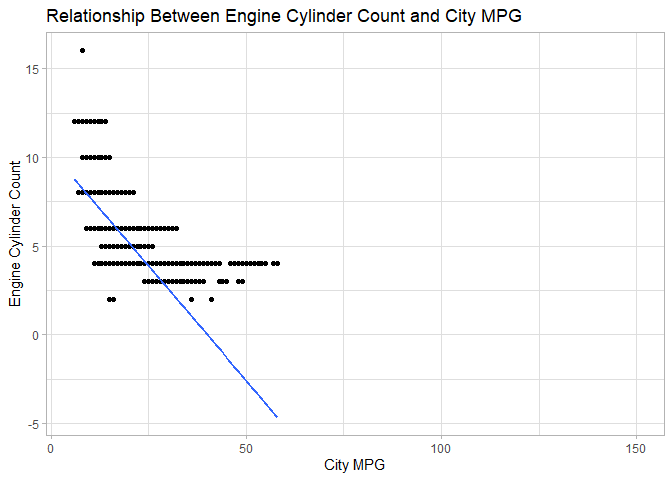

```r
database %>%
  ggplot(aes(x = `City.MPG..FT1.`, y = `Engine.Cylinders`, stringr::str_wrap(V1, 15))) +
  geom_point() +
  geom_smooth(se = FALSE, method = "lm") +
  labs(title = "Relationship Between Engine Cylinder Count and City MPG",
  x = "City MPG", y = "Engine Cylinder Count") +
  theme_light() +
  theme(plot.caption = element_text(hjust = 0))
```

In the scatter plot above, you can see that as Engine Cylinder Count decreases, City MPG increases. Fuel efficiency increases with fewer engine cylinders.

### Highway MPG of Compact Cars Over Time

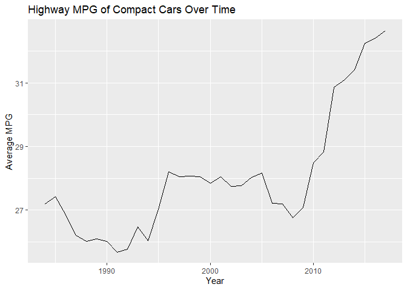

```r
database %>%
  filter(Class == "Compact Cars") %>%
  group_by(Year) %>%
  summarise(avg_mpg = mean(Highway.MPG..FT1.)) %>%
  ggplot(aes(x = Year, y = avg_mpg)) +
  geom_line() +
  labs(title = "Highway MPG of Compact Cars Over Time", y = "Average MPG")
```

In the line graph above, it is clear that over time, Highway MPG of Compact Cars has improved. There were some years that the average MPG of the class dropped below previous years, but the average MPG begins to increase heavily around 2009.

### Annual Fuel Cost for Honda

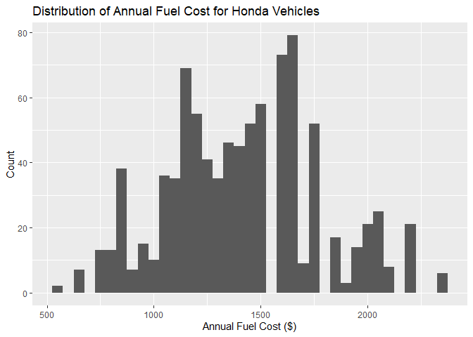

```r
database %>%
  filter(Make == "Honda") %>%
  ggplot(aes(x = Annual.Fuel.Cost..FT1.)) +
  geom_histogram(binwidth = 50) +
  labs(title = "Distribution of Annual Fuel Cost for Honda Vehicles", x = "Annual Fuel Cost ($)", y = "Count")
```

As shown in the histogram above, the annual fuel cost distribution for Honda vehicles ranges from $500 to $2400, with the highest count of the vehicles costing $1650 in fuel annually.

### Highway MPG for Ferrari

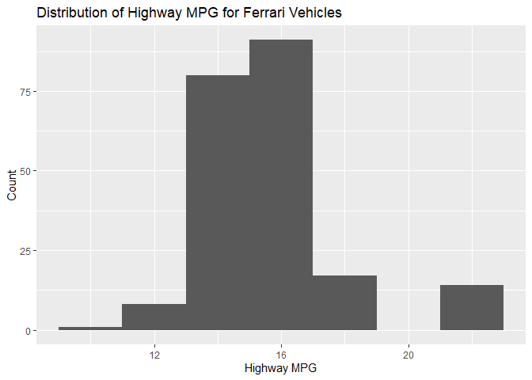

```r
database %>%
  filter(Make == "Ferrari") %>%
  ggplot(aes(x = Highway.MPG..FT1.)) +
  geom_histogram(binwidth = 2) +
  labs(title = "Distribution of Highway MPG for Ferrari Vehicles", x = "Highway MPG", y = "Count")
```

As seen in the histogram above, Highway MPG for Ferrari vehicles is not ideal as they range between 10 and 22 MPG, with the highest count of vehicles having 16 Highway MPG. This is a result of Ferrari producing their vehicles for performance and speed, using engines with more cylinders and larger displacements.

### Fuel Type & Displacement vs. Highway MPG

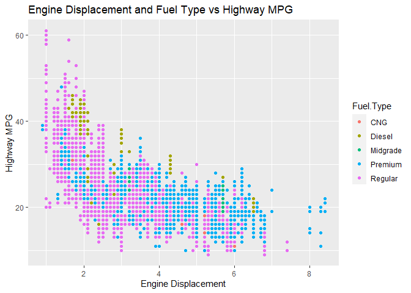

```r
database_fuel <- database %>%
  filter(!grepl("Electricity|and|or", Fuel.Type))
database_fuel %>%
  ggplot(aes(x = Engine.Displacement, y = Highway.MPG..FT1., color = Fuel.Type)) +
  geom_point() +
  labs(title = "Engine Displacement and Fuel Type vs Highway MPG", x = "Engine Displacement", y = "Highway MPG")
```

As seen in this scatterplot above, there is no real relationship between Fuel Type and Highway MPG as higher Engine Displacement tends to drop fuel efficiency and therefore Highway MPG regardless of the Fuel Type used. The scatterplot just appears to show more Regular fuel vehicles being more efficient, but I believe that is just a result of there being more vehicles with smaller engine displacements than there are vehicles with higher engine displacements.

## Data Exploration - K Means Clustering

```r
database_clean <- database %>%
  select(-c(1:10))
database_f <- database_clean %>%
  select(-c(9:20)) %>%
  drop_na()
database_final <- database_f %>%
  select(-c(3:7))
#Cleaning up non-numerical, unneeded, and NA data.

set.seed(1)
car_clusters <- kmeans(database_final[, 2:3], centers = 5, nstart = 10)
car_clusters
```

```
## K-means clustering with 5 clusters of sizes 229, 657, 2108, 1522, 721
##
## Cluster means:
##   Engine.Displacement City.MPG..FT1.
## 1            1.627511       30.25764
## 2            5.131355       12.65145
## 3            2.729364       16.89516
## 4            2.194284       20.29041
## 5            1.826907       24.50624
##
## Clustering vector:
##    [1] 3 3 3 3 2 2 2 2 3 3 4 4 3 3 3 3 3 3 3 3 3 3 3 3 3 3 3 3 5 5 3 3 3 3 3 3 3
##   [38] 3 3 3 4 4 4 4 3 3 3 3 3 3 2 2 2 2 4 4 3 3 3 3 3 3 4 4 4 4 5 3 3 3 3 3 3 4
##   [75] 4 4 4 4 4 3 3 3 3 3 3 3 3 5 5 3 3 3 3 3 3 3 3 4 4 3 3 4 4 4 4 3 3 3 3 4 4
##  [112] 4 4 4 4 3 3 3 3 3 3 3 3 3 3 3 3 3 3 3 3 3 2 3 3 4 4 3 3 3 3 3 3 3 3 3 3 3
```

[output cut: 147 more lines]

```r
car_clusters$centers
```

```
##   Engine.Displacement City.MPG..FT1.
## 1            1.627511       30.25764
## 2            5.131355       12.65145
## 3            2.729364       16.89516
## 4            2.194284       20.29041
## 5            1.826907       24.50624
```

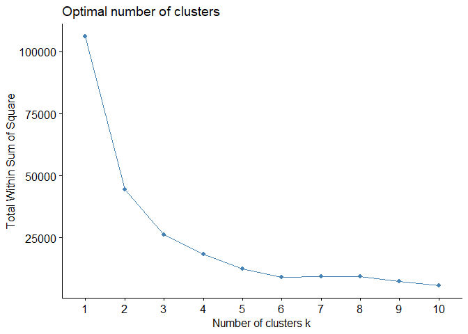

```r
set.seed(1)
options(scipen = 999)
fviz_nbclust(database_final[, 2:3], kmeans, method = "wss")
```

The elbow plot above shows that 2 is the ideal amount of clusters. With the cluster size of 5, its measure of internal cohesion and external separation was 88.9%. There are 5 groups of within ss.

# Part 2

## Models

### City MPG Model

```r
database_mod <- database %>%
  select(City.MPG..FT1., Engine.Cylinders, Engine.Displacement, Combined.MPG..FT1.) %>%
  drop_na()

set.seed(123)
car_split <- initial_split(database_mod, prop = 0.75)
car_training <- training(car_split)
car_testing <- testing(car_split)

nrow(car_training) + nrow(car_testing)
```

```
## [1] 37977
```

```r
cor_matrix_car <- round(cor(database_mod), 2)
melt_car_cor <- melt(cor_matrix_car)
head(melt_car_cor)
```

```
##                  Var1             Var2 value
## 1      City.MPG..FT1.   City.MPG..FT1.  1.00
## 2    Engine.Cylinders   City.MPG..FT1. -0.70
## 3 Engine.Displacement   City.MPG..FT1. -0.74
## 4  Combined.MPG..FT1.   City.MPG..FT1.  0.99
## 5      City.MPG..FT1. Engine.Cylinders -0.70
## 6    Engine.Cylinders Engine.Cylinders  1.00
```

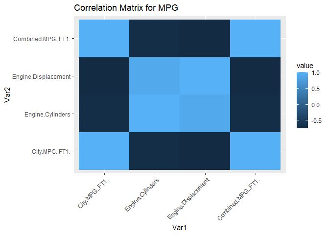

```r
melt_car_cor %>%
  ggplot(aes(x = Var1, y = Var2, fill = value)) +
  geom_tile() +
  theme(axis.text.x = element_text(angle = 45, hjust = 1)) +
  labs(title = "Correlation Matrix for MPG")
```

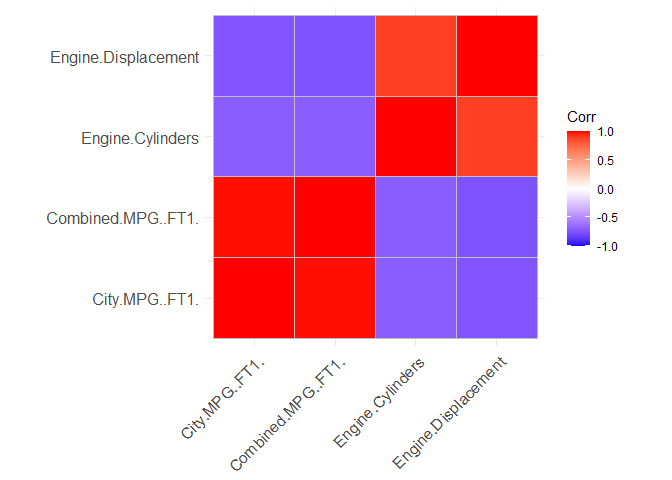

```r
ggcorrplot(cor(database_mod), p.mat = cor_pmat(database_mod), hc.order = TRUE)
```

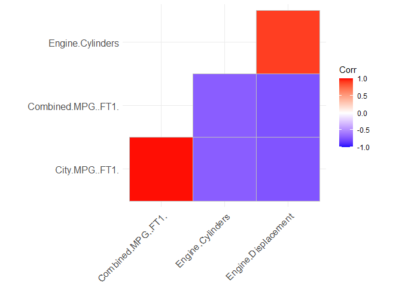

```r
ggcorrplot(cor(database_mod), p.mat = cor_pmat(database_mod), hc.order = TRUE, type='lower')
```

```r
training_lm_model2 <- lm(`City.MPG..FT1.` ~ ., data = car_training)
training_lm_model3 <- lm(`City.MPG..FT1.` ~ Engine.Cylinders, data = car_training)

options(scipen = 999)

summary(training_lm_model2)
```

```
##
## Call:
## lm(formula = City.MPG..FT1. ~ ., data = car_training)
##
## Residuals:
##     Min      1Q  Median      3Q     Max
## -2.2913 -0.5803 -0.0066  0.4052  7.7825
##
## Coefficients:
##                      Estimate Std. Error t value             Pr(>|t|)
## (Intercept)         -0.135662   0.045448  -2.985              0.00284 **
## Engine.Cylinders    -0.159630   0.006380 -25.020 < 0.0000000000000002 ***
## Engine.Displacement  0.144633   0.008743  16.543 < 0.0000000000000002 ***
## Combined.MPG..FT1.   0.915496   0.001401 653.599 < 0.0000000000000002 ***
## ---
## Signif. codes:  0 '***' 0.001 '**' 0.01 '*' 0.05 '.' 0.1 ' ' 1
##
## Residual standard error: 0.8009 on 28478 degrees of freedom
## Multiple R-squared:  0.9718, Adjusted R-squared:  0.9718
## F-statistic: 3.272e+05 on 3 and 28478 DF,  p-value: < 0.00000000000000022
```

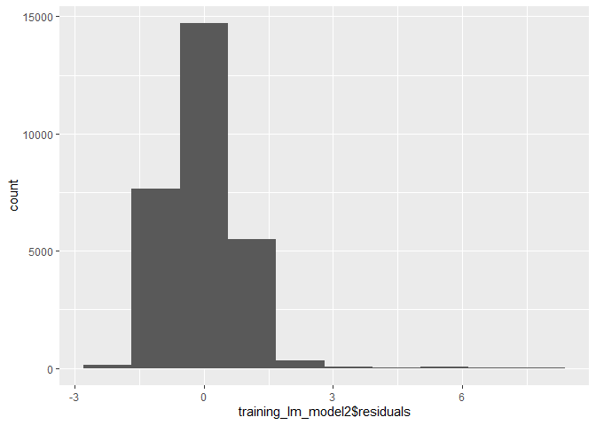

```r
ggplot(data = training_lm_model2) +
  aes(x = training_lm_model2$residuals) +
  geom_histogram(bins = 10)
```

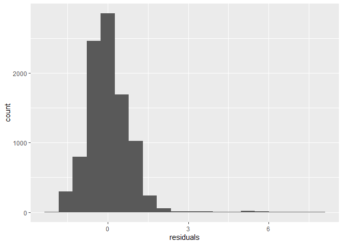

```r
testing_predictions <- predict(training_lm_model2, newdata = car_testing)

testing_residuals <- data.frame(car_testing$City.MPG..FT1., testing_predictions, residuals = car_testing$City.MPG..FT1. - testing_predictions)

testing_residuals %>%
  ggplot(aes(x = residuals)) +
  geom_histogram(bins = 20)
```

As shown in the residuals histogram for the City MPG Model, the distribution is somewhat symmetric. The errors for the model fall close to zero, implying that there is little bias. The R-squared value is 0.9718, showing that 97.18% of the variation can be explained by the Engine Cylinder, Engine Displacement, and Combined MPG variables. The tested data histogram is also symmetric.

### Highway MPG Model

```r
database_mod_hwy <- database %>%
  select(Highway.MPG..FT1., Engine.Cylinders, Engine.Displacement, Combined.MPG..FT1.) %>%
  drop_na()

set.seed(123)
car_split_hwy <- initial_split(database_mod_hwy, prop = 0.75)
car_training_hwy <- training(car_split_hwy)
car_testing_hwy <- testing(car_split_hwy)

cor_matrix_car_hwy <- round(cor(database_mod_hwy), 2)
melt_car_cor_hwy <- melt(cor_matrix_car_hwy)
head(melt_car_cor_hwy)
```

```
##                  Var1              Var2 value
## 1   Highway.MPG..FT1. Highway.MPG..FT1.  1.00
## 2    Engine.Cylinders Highway.MPG..FT1. -0.65
## 3 Engine.Displacement Highway.MPG..FT1. -0.71
## 4  Combined.MPG..FT1. Highway.MPG..FT1.  0.97
## 5   Highway.MPG..FT1.  Engine.Cylinders -0.65
## 6    Engine.Cylinders  Engine.Cylinders  1.00
```

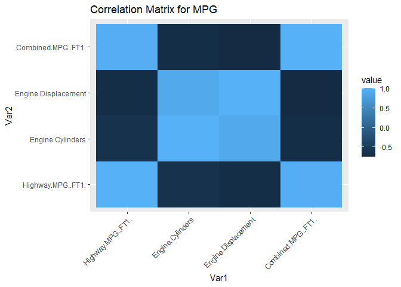

```r
melt_car_cor_hwy %>%
  ggplot(aes(x = Var1, y = Var2, fill = value)) +
  geom_tile() +
  theme(axis.text.x = element_text(angle = 45, hjust = 1)) +
  labs(title = "Correlation Matrix for MPG")
```

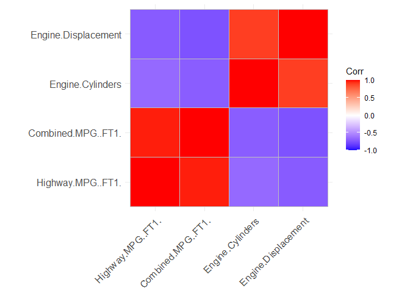

```r
ggcorrplot(cor(database_mod_hwy), p.mat = cor_pmat(database_mod_hwy), hc.order = TRUE)
```

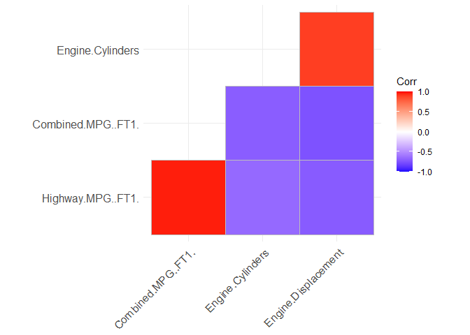

```r
ggcorrplot(cor(database_mod_hwy), p.mat = cor_pmat(database_mod_hwy), hc.order = TRUE, type='lower')
```

```r
training_lm_model4 <- lm(`Highway.MPG..FT1.` ~ ., data = car_training_hwy)
training_lm_model5 <- lm(`Highway.MPG..FT1.` ~ Engine.Cylinders, data = car_training_hwy)

options(scipen = 999)

summary(training_lm_model4)
```

```
##
## Call:
## lm(formula = Highway.MPG..FT1. ~ ., data = car_training_hwy)
##
## Residuals:
##      Min       1Q   Median       3Q      Max
## -11.5482  -0.8380   0.0373   0.9168   6.8117
##
## Coefficients:
##                      Estimate Std. Error t value             Pr(>|t|)
## (Intercept)          0.535175   0.080096   6.682      0.0000000000241 ***
## Engine.Cylinders     0.336531   0.011244  29.929 < 0.0000000000000002 ***
## Engine.Displacement -0.307480   0.015408 -19.956 < 0.0000000000000002 ***
## Combined.MPG..FT1.   1.122562   0.002469 454.744 < 0.0000000000000002 ***
## ---
## Signif. codes:  0 '***' 0.001 '**' 0.01 '*' 0.05 '.' 0.1 ' ' 1
##
## Residual standard error: 1.411 on 28478 degrees of freedom
## Multiple R-squared:  0.9405, Adjusted R-squared:  0.9405
## F-statistic: 1.501e+05 on 3 and 28478 DF,  p-value: < 0.00000000000000022
```

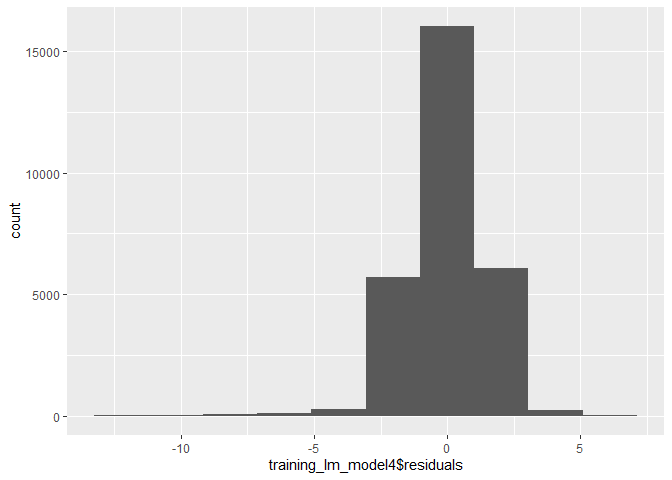

```r
ggplot(data = training_lm_model4) +
  aes(x = training_lm_model4$residuals) +
  geom_histogram(bins = 10)
```

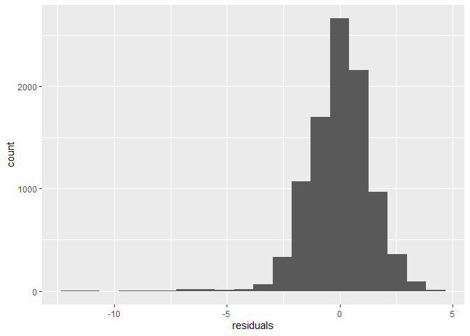

```r
testing_predictions_hwy <- predict(training_lm_model4, newdata = car_testing_hwy)

testing_residuals_hwy <- data.frame(car_testing_hwy$Highway.MPG..FT1., testing_predictions_hwy, residuals = car_testing_hwy$Highway.MPG..FT1. - testing_predictions_hwy)

testing_residuals_hwy %>%
  ggplot(aes(x = residuals)) +
  geom_histogram(bins = 20)
```

For the Highway MPG Model, the residual histogram is quite symmetric with the errors falling close to zero, implying less bias. The R-squared value for this model is 0.9405, explaining that 94.05% of the variances can be explained by the variables. The tested data histogram also displays as symmetric, although not as much as the residual histogram.

### Class Model

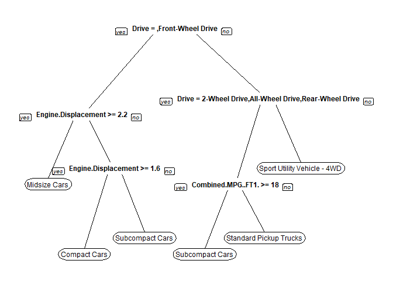

```r
database_mod_class <- database %>%
  select(Engine.Cylinders, Engine.Displacement, Combined.MPG..FT1., Class, Drive, Combined.Utility.Factor) %>%
  drop_na()

set.seed(1)

car_class_split <- initial_split(database_mod_class, prop = 0.6)
car_class_training_data <- training(car_class_split)
car_class_validation_data <- testing(car_class_split)

set.seed(1)
car_class_tree <- rpart(Class ~ Engine.Displacement + Combined.Utility.Factor + Combined.MPG..FT1. + Drive, data = car_class_training_data, parms = list(split = "gini"), method = "class")

prp(car_class_tree, faclen = 0, varlen =0, cex = 0.75, yesno = 2)
```

```r
printcp(car_class_tree)
```

```
##
## Classification tree:
## rpart(formula = Class ~ Engine.Displacement + Combined.Utility.Factor +
##     Combined.MPG..FT1. + Drive, data = car_class_training_data,
##     method = "class", parms = list(split = "gini"))
##
## Variables actually used in tree construction:
## [1] Combined.MPG..FT1.  Drive               Engine.Displacement
##
## Root node error: 19521/22786 = 0.85671
##
## n= 22786
##
##         CP nsplit rel error  xerror      xstd
## 1 0.031120      0   1.00000 1.00000 0.0027093
## 2 0.023257      2   0.93776 0.93776 0.0030733
## 3 0.015624      3   0.91450 0.91450 0.0031850
## 4 0.010758      4   0.89888 0.90093 0.0032450
## 5 0.010000      5   0.88812 0.89319 0.0032777
```

```r
car_class_prediction_test <- predict(car_class_tree, newdata = car_class_training_data, type = "class")
prediction_test2 <- predict(car_class_tree, newdata = car_class_validation_data, type = "class")

car_class_training_data$predicted <- car_class_prediction_test

options(scipen = 999)

confusionMatrix(car_class_prediction_test, as.factor(car_class_training_data$Class))
```

```
## Confusion Matrix and Statistics
##
##                                     Reference
## Prediction                           Compact Cars Large Cars
##   Compact Cars                               1198         33
##   Large Cars                                    0          0
##   Midsize-Large Station Wagons                  0          0
##   Midsize Cars                                974        384
##   Midsize Station Wagons                        0          0
##   Minicompact Cars                              0          0
##   Minivan - 2WD                                 0          0
##   Minivan - 4WD                                 0          0
##   Small Pickup Trucks                           0          0
##   Small Pickup Trucks 2WD                       0          0
##   Small Pickup Trucks 4WD                       0          0
##   Small Sport Utility Vehicle 2WD               0          0
##   Small Sport Utility Vehicle 4WD               0          0
##   Small Station Wagons                          0          0
##   Special Purpose Vehicle                       0          0
##   Special Purpose Vehicle 2WD                   0          0
##   Special Purpose Vehicle 4WD                   0          0
##   Special Purpose Vehicles                      0          0
##   Special Purpose Vehicles/2wd                  0          0
##   Special Purpose Vehicles/4wd                  0          0
##   Sport Utility Vehicle - 2WD                   0          0
##   Sport Utility Vehicle - 4WD                 261         43
##   Standard Pickup Trucks                      175        212
##   Standard Pickup Trucks 2WD                    0          0
##   Standard Pickup Trucks 4WD                    0          0
##   Standard Pickup Trucks/2wd                    0          0
##   Standard Sport Utility Vehicle 2WD            0          0
##   Standard Sport Utility Vehicle 4WD            0          0
##   Subcompact Cars                             657        414
##   Two Seaters                                   0          0
##   Vans                                          0          0
##   Vans Passenger                                0          0
##   Vans, Cargo Type                              0          0
##   Vans, Passenger Type                          0          0
##                                     Reference
## Prediction                           Midsize-Large Station Wagons Midsize Cars
```

[output cut: 1158 more lines]

```
## Pos Pred Value                         NaN                     NaN
## Neg Pred Value                  0.99995611                 0.98828
## Prevalence                      0.00004389                 0.01172
## Detection Rate                  0.00000000                 0.00000
## Detection Prevalence            0.00000000                 0.00000
## Balanced Accuracy               0.50000000                 0.50000
##                      Class: Vans, Passenger Type
## Sensitivity                             0.000000
## Specificity                             1.000000
## Pos Pred Value                               NaN
## Neg Pred Value                          0.991135
## Prevalence                              0.008865
## Detection Rate                          0.000000
## Detection Prevalence                    0.000000
## Balanced Accuracy                       0.500000
```

With the variables I filtered from the original dataset, the model was not very accurate. The overall statistics show that the model’s accuracy was 0.2391. The No Information Rate was 0.1433. Because the accuracy was larger than the No Information Rate, you could say the model was significant.